# Describing Data worksheet

MC 451 · Chapter 12 · Part 2 of 3 of the Twitch job

## The case

You are the data analyst on a small study. Your client is the channel manager at a small creator agency that represents about a dozen Twitch streamers. The agency is about to pitch a sponsor on how engaged its streamers’ chats are. Before the pitch, the manager wants three questions answered with data:

1. Does chat in gaming channels look different from chat in non-gaming channels?
2. Does a bigger audience change how people write?
3. How much of chat is reaction (an emote, a cheer, a single word) and how much is commentary?

**Where the job stands.** In Data Wrangling you built the table, `data/twitch_analysis.RDS`, with your thirty hand-coded messages inside it. The manager has not seen a number from it yet.

**Your job.** Show the manager what is in the table before anything is tested: how often each category occurs, how long messages run, how two categories line up, and what the patterns look like in a chart. The manager does not read R, so every **Write:** prompt is a note to them.

## Your assignment

| Part | What you do | Why the client needs it |
| --- | --- | --- |
| 1 | Frequency tables: count how often each category occurs | The manager sees how much of chat is gaming, large-audience, and reaction |
| 2 | The three numbers: the mean, median, and standard deviation of message length | “How people write” becomes numbers the manager can compare |
| 3 | The cross-tabulation: count viewer band against channel type | The manager sees whether audience size and channel type go together |
| 4 | Three figures, each with alt text, a disclosure sentence, and an interpretation | A chart is what the manager can put in front of a sponsor |
| Last | Explain this stage to the client, in one short paragraph | The manager gets what you found in plain language |

The code sits in gray boxes called chunks, as in Data Wrangling. Work through them in order:

1. Replace each blank, shown as `___`, with the code it needs.
2. Click **Run Cell** at the top left of the gray box.
3. Compare what R prints with **What you should see**.

Where the worksheet says **Write:**, type your answer in your own words. Every task has a **Help** link. It opens the page that explains that task: what the blank needs, where to click, and what to do when R prints an error.

## What to submit

**75 points.** Due Friday, November 20, 11:59 PM, in Blackboard, under **Describing Data in R**.

You turn in an R assignment as one ZIP file: your whole course workspace, the folder you have open in VS Code, packed into a single file. [How to make the ZIP](https://aura-lab.siue.edu/v2v-hub/guides/mc451/11-render-a-quarto-document.html#submit-your-work-as-one-zip-file). The ZIP must hold:

- this worksheet, with every blank and every **Write:** filled
- the HTML file with the same name, which you make in **Before you submit**
- your [AI-use log](https://aura-lab.siue.edu/v2v-hub/resources/AI-use-log.docx)

Rubric: [Describing Data in R rubric](https://aura-lab.siue.edu/v2v-hub/resources/rubrics/MC451-rubric-describing-data-in-r.pdf).

## Setup

```r
library(tidyverse)     # tables and charts
library(v2v)           # theme_v2v() and the course palette
options(scipen = 10)  # long numbers such as timestamps print in full; p-values keep the usual form
analysis <- read_rds("data/twitch_analysis.RDS")  # the table worksheet 1 saved
dir.create("figures", showWarnings = FALSE)        # where every chart is saved
analysis %>% count(reaction_only)  # your hand-coded variable made it through
```

```
# A tibble: 3 × 2
  reaction_only     n
  <fct>         <int>
1 commentary       16
2 reaction         14
3 <NA>          35237
```

**What you should see:** your two coded groups adding to `30`, and `NA` with `35237`. [Help with Setup](https://aura-lab.siue.edu/v2v-hub/resources/help/describing-data.html#setup)

## Part 1: Frequency tables

### Task 1.1: Channel type

A frequency table says how often each category occurs. This one is done for you as the model.

```r
analysis %>%
  count(channel_type) %>%                  # messages per category
  mutate(percent = round(100 * n / sum(n), 1))  # and as a share of all messages
```

```
# A tibble: 3 × 3
  channel_type     n percent
  <fct>        <int>   <dbl>
1 gaming       31309    88.8
2 non-gaming    3457     9.8
3 <NA>           501     1.4
```

**What you should see:** `gaming` `31309` (88.8%), `non-gaming` `3457` (9.8%), and `NA` `501` (1.4%). [Help with Task 1.1](https://aura-lab.siue.edu/v2v-hub/resources/help/describing-data.html#task-1-1)

### Task 1.2: Viewer band

Build the same table for `viewer_band`.

```r
analysis %>%
  count(viewer_band) %>%
  mutate(percent = round(100 * n / sum(n), 1))
```

```
# A tibble: 3 × 3
  viewer_band     n percent
  <fct>       <int>   <dbl>
1 small       27766    78.7
2 medium       5501    15.6
3 large        2000     5.7
```

**What you should see:** `small` `27766` (78.7%), `medium` `5501` (15.6%), `large` `2000` (5.7%). [Help with Task 1.2](https://aura-lab.siue.edu/v2v-hub/resources/help/describing-data.html#task-1-2)

### Task 1.3: Your hand-coded variable

Only thirty messages carry a code. Keep those rows first, or the table is mostly `NA`.

```r
analysis %>%
  filter(!is.na(reaction_only)) %>%  # only the thirty coded messages
  count(reaction_only) %>%
  mutate(percent = round(100 * n / sum(n), 1))
```

```
# A tibble: 2 × 3
  reaction_only     n percent
  <fct>         <int>   <dbl>
1 commentary       16    53.3
2 reaction         14    46.7
```

**What you should see:** two rows adding to `30`. [Help with Task 1.3](https://aura-lab.siue.edu/v2v-hub/resources/help/describing-data.html#task-1-3)

**Write:** two to three sentences for the client on the three tables: what they show, and what they do not. Name the numbers.

These tables show that of the messages, 88.8% are from gaming channels while 9.8% are from non-gaming channels. Around half of the dataset are coded as commentary, at 16 (53.3%), while 14 of the 30 are coded as reaction (46.7%). The viewer band table shows that most of the messages are from small channels, 78.7%. Then 15.6% are from medium channels, and 5.7% from large channels. Though, these tables do not make any inferences about the data and the way they are related.

## Part 2: The three numbers

### Task 2.1: Message length, all messages

```r
analysis %>%
  summarize(
    n      = sum(!is.na(message_length)),
    mean   = mean(message_length, na.rm = TRUE),
    median = median(message_length, na.rm = TRUE),
    sd     = sd(message_length, na.rm = TRUE)
  )
```

```
# A tibble: 1 × 4
      n  mean median    sd
  <int> <dbl>  <int> <dbl>
1 35263  29.0     17  41.2
```

**What you should see:** `n` `35263`, `mean` `29.0`, `median` `17`, `sd` `41.2`. [Help with Task 2.1](https://aura-lab.siue.edu/v2v-hub/resources/help/describing-data.html#task-2-1)

### Task 2.2: By channel type, and by your code

Fill the grouping variable, then the filter that keeps only your coded messages.

```r
analysis %>%
  filter(!is.na(channel_type)) %>%
  group_by(channel_type) %>%
  summarize(
    n      = n(),
    mean   = mean(message_length, na.rm = TRUE),
    median = median(message_length, na.rm = TRUE),
    sd     = sd(message_length, na.rm = TRUE)
  )
```

```
# A tibble: 2 × 5
  channel_type     n  mean median    sd
  <fct>        <int> <dbl>  <int> <dbl>
1 gaming       31309  28.5     17  38.5
2 non-gaming    3457  33.7     16  60.7
```

```r
analysis %>%
  filter(!is.na(reaction_only)) %>%
  group_by(reaction_only) %>%

  summarize(
    n      = n(),
    mean   = mean(message_length),
    median = median(message_length),
    sd     = sd(message_length),
    max    = max(message_length)
  )
```

```
# A tibble: 2 × 6
  reaction_only     n  mean median    sd   max
  <fct>         <int> <dbl>  <dbl> <dbl> <int>
1 commentary       16  30.1     21  28.6   119
2 reaction         14  15.6      9  22.5    90
```

**What you should see:** `gaming` n `31309`, mean `28.5`, median `17`, sd `38.5`; `non-gaming` n `3457`, mean `33.7`, median `16`, sd `60.7`. Then one row for each of your two coded groups. [Help with Task 2.2](https://aura-lab.siue.edu/v2v-hub/resources/help/describing-data.html#task-2-2)

**Write:** two to three sentences for the client. Where do the mean and the median disagree, and what does the gap tell you about the shape of message length?

## Part 3: The cross-tabulation

### Task 3.1: Viewer band by channel type

```r
analysis %>%
  filter(!is.na(channel_type)) %>%
  count(viewer_band, channel_type) %>%                   # viewer band as the rows, channel type as the columns
  pivot_wider(names_from = channel_type, values_from = n, values_fill = 0)   # one column per channel type
```

```
# A tibble: 3 × 3
  viewer_band gaming `non-gaming`
  <fct>        <int>        <int>
1 small        25309         2457
2 medium        4000         1000
3 large         2000            0
```

**What you should see:** three rows of counts. `small`: `25309` gaming, `2457` non-gaming. `medium`: `4000` and `1000`. `large`: `2000` and `0`. [Help with Task 3.1](https://aura-lab.siue.edu/v2v-hub/resources/help/describing-data.html#task-3-1)

### Task 3.2: As proportions of each band

The same counts as shares of each band.

```r
analysis %>%
  filter(!is.na(channel_type)) %>%
  count(viewer_band, channel_type) %>%
  group_by(viewer_band) %>%                           # shares within each band, not across the table
  mutate(share = round(n / sum(n), 3))
```

```
# A tibble: 5 × 4
# Groups:   viewer_band [3]
  viewer_band channel_type     n share
  <fct>       <fct>        <int> <dbl>
1 small       gaming       25309 0.912
2 small       non-gaming    2457 0.088
3 medium      gaming        4000 0.8
4 medium      non-gaming    1000 0.2
5 large       gaming        2000 1
```

**What you should see:** non-gaming is `0.088` of the small band and `0.2` of the medium band. The large band has no non-gaming row. [Help with Task 3.2](https://aura-lab.siue.edu/v2v-hub/resources/help/describing-data.html#task-3-2)

**Write:** two to three sentences for the client on the cross-tabulation. What does it show, and what can it not show yet?

## Part 4: Figures

Each figure is built, saved to `figures/` by the code that makes it, and carries alt text you write on its `#| fig-alt:` line. After each one, **Write:** one sentence disclosing a choice you made in it (a cap on an axis, which categories you kept, a bin width), and two to three sentences of interpretation for the client.

### Task 4.1: Channel type within each viewer band

A proportion bar chart of the cross-tabulation. Fill the fill aesthetic and the position that makes every bar the same height.

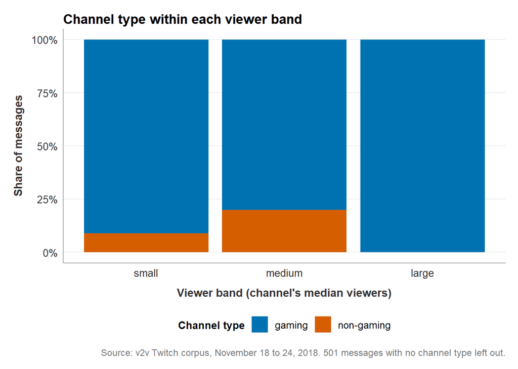

Figure 1

```r
fig_band_type <- analysis %>%
  filter(!is.na(channel_type)) %>%
  ggplot(aes(x = viewer_band, fill = channel_type)) +
  geom_bar(position = "fill") +                        # every bar scaled to 100%
  scale_y_continuous(labels = scales::percent_format()) +
  scale_fill_v2v() +
  labs(title   = "Channel type within each viewer band",
       x       = "Viewer band (channel's median viewers)",
       y       = "Share of messages",
       fill    = "Channel type",
       caption = "Source: v2v Twitch corpus, November 18 to 24, 2018. 501 messages with no channel type left out.") +
  theme_v2v()

fig_band_type
ggsave("figures/band-by-type.png", fig_band_type, width = 7, height = 4.5, dpi = 300)
```

**What you should see:** three bars of equal height, and `band-by-type.png` in `figures/`. [Help with Task 4.1](https://aura-lab.siue.edu/v2v-hub/resources/help/describing-data.html#task-4-1)

**Write:** the disclosure sentence, then two to three sentences of interpretation.

*Your answer:* This chart shows the percentage shares of messages depending on channel type and sorted by viewer band. Since no large non-gaming channels are in the dataset, the Large band is 100% gaming. The medium band has the highest percentage of non-gaming channels at 20% while the small band has only 8.8%. Still, the gaming channels dominate every band.

### Task 4.2: Message length by your code

The thirty coded messages, as a boxplot. Fill the variable on the x axis and the geom.

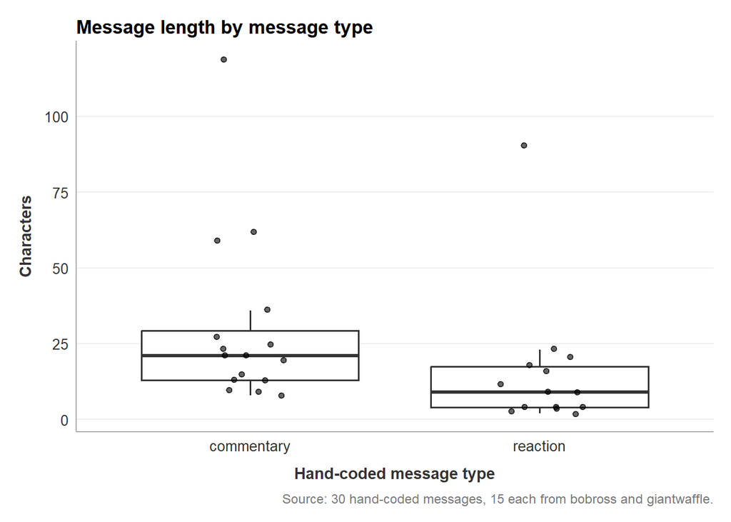

Figure 2

```r
fig_length_reaction <- analysis %>%
  filter(!is.na(reaction_only)) %>%
  ggplot(aes(x = reaction_only, y = message_length)) +
  geom_boxplot(outlier.shape = NA) +   # no outlier dots here; the points below show every message
  geom_jitter(width = 0.15, alpha = 0.6) +   # every one of the thirty, shown as a point
  labs(title   = "Message length by message type",
       x       = "Hand-coded message type",
       y       = "Characters",
       caption = "Source: 30 hand-coded messages, 15 each from bobross and giantwaffle.") +
  theme_v2v()

fig_length_reaction
ggsave("figures/length-by-reaction.png", fig_length_reaction, width = 6, height = 4.5, dpi = 300)
```

**What you should see:** two boxes, and `length-by-reaction.png` in `figures/`. [Help with Task 4.2](https://aura-lab.siue.edu/v2v-hub/resources/help/describing-data.html#task-4-2)

**Write:** the disclosure sentence, then two to three sentences of interpretation.

*Your answer:* This chart shows how message type, wether commentary or reaction, connect to the length of the message. The commentary messages tend to have a higher message length than the reaction messages do, and more extreme outliers. The reaction messages have fevwer extreme outliers, and the median is lower than that of the commentary messages. This makes sense because reaction messages are coded as such when they are a single word or cheer, while commentary messages are coded as such if there are more than two words.